# Estudo de artigo: Confiabilidade e Precisão na Estimação de Médias

Julio M. Singer, Carmen Diva Saldiva de André e Clósvis de Araújo Peres.

[figure not shown]

[Bruna Wundervald](https://brunaw.github.io/)  
`brunadaviesw at gmail.com`  
Departamento de Estatística - UFPR

# Introdução

Problemas compostos por medidas repetidas em um mesmo indivíduo podem ser avaliados por meio de um modelo de análise de variância, como:

$$\rho = \frac{\sigma^2_a}{(\sigma^2_a + \sigma^2_e)}$$

Assim, observa-se que:

- Quanto menor a variância amostral intra-indivíduos (mais homogeneidade), $\sigma^2_e$, em relação à variância amostra inter-indivíduos, $\sigma^2_a$, mais próximo de 1 é o valor de $\rho$.
- Analogamente, o valor de $\rho$ cai quando $\sigma^2_e$ aumenta em relação a $\sigma^2_a$.

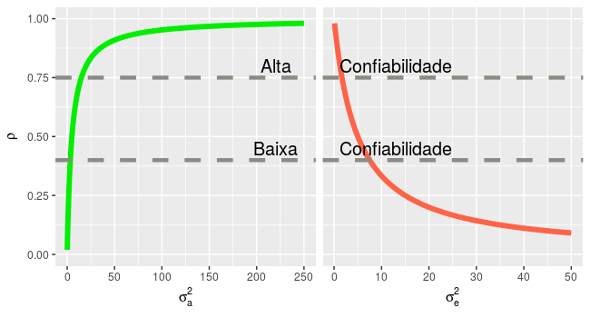

Figura 1: Comportamento da correlação intraclasse variando $\sigma^2_a$ e $\sigma^2_e$

```r
library(ggplot2)
library(gridExtra)
library(tidyverse)
library(grid)
library(gtable)

rho <- function(s.a, s.e){
  r <- s.a/(s.a + s.e)
}
rho.a <- Vectorize(rho, "s.a")
rho.e <- Vectorize(rho, "s.e")

r.a <- seq(0.1, 250, l = 1000) %>% rho.e(s.e = 5)
r.e <- seq(50, 0.1, l = 1000) %>% rho.a(s.a = 5)

p1 <- data.frame(s = seq(0.1, 250, l = 1000), r.a = r.a) %>%
  ggplot(aes(x = s, y = r.a)) +
  geom_line( colour = "green2", size = 2) +
  xlab(expression(sigma[a]^2)) +
  ylab(expression(rho)) +
  geom_hline(aes(yintercept = 0.75),
             linetype = "dashed", size = 1.5, color = "ivory4") +
  geom_hline(aes(yintercept = 0.4),
             linetype = "dashed", size = 1.5, color = "ivory4") +
    annotate("text", x = 220, y = 0.80,
           label = "Alta",
           parse = TRUE, size = 5) +
    annotate("text", x = 220, y = 0.45,
           label = "Baixa",
           parse = TRUE, size = 5) +
  scale_y_continuous(limits = c(0, 1))


p2 <- data.frame(s = seq(50, 0.1, l = 1000), r.e = r.e) %>%
  ggplot(aes(x = s, y = r.e)) +
  geom_line( colour = "tomato", size = 2) +
  xlab(expression(sigma[e]^2)) +
  geom_hline(aes(yintercept = 0.75),
             linetype = "dashed", size = 1.5, color = "ivory4") +
  geom_hline(aes(yintercept = 0.4),
             linetype = "dashed", size = 1.5, color = "ivory4") +
  annotate("text", x = 13, y = 0.80,
           label = "Confiabilidade",
           parse = TRUE, size = 5) +
    annotate("text", x = 13, y = 0.45,
           label = "Confiabilidade",
           parse = TRUE, size = 5) +
    scale_y_continuous(limits = c(0, 1))

gl <- lapply(list(p1, p2), ggplotGrob)

widths <- do.call(unit.pmax, lapply(gl, "[[", "widths"))
heights <- do.call(unit.pmax, lapply(gl, "[[", "heights"))
lg <- lapply(gl, function(g) {g$widths <- widths; g$heights <- heights; g})
gt = cbind(lg[[1]], lg[[2]][, -(1:3)], size = "first")

gt$widths[5] = unit(0, "lines")
grid.newpage()
grid.draw(gt)
```

Além disso, a média de $m > 1$ observações é um estimador melhor/mais confiável da média populacional do que uma única observação. Assim, o modelo:

$$\bar y_{i} = \mu + a_i + \bar e_{i}$$
Tem coeficiente de correlação uintraclasse (confiabilidade média de m réplicas) dado por:

$$\rho = \frac{\sigma^2_a}{(\sigma^2_a + \sigma^2_e/m)}$$
E temos que a **confiabilidade média de m réplicas depende de m**, pois:

$$\rho_m = \frac{m \rho}{1 + (m-1)\rho}$$

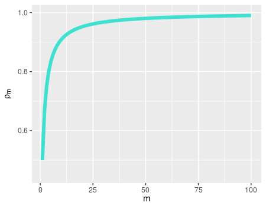

Figura 2: Comportamento de $\rho_m$ com m variando e $\rho$ fixo

```r
rho.m <- function(m, rho){
  r <- m*rho/(1 + (m-1)*rho)
}
rho.m <- Vectorize(rho.m, "m")

r.m <- 1:100 %>% rho.m(rho = 0.5)

data.frame(s = 1:100, r.m = r.m) %>%
  ggplot(aes(x = s, y = r.m)) +
  geom_line( colour = "turquoise", size = 2) +
  xlab(expression(m)) +
  ylab(expression(rho[m]))  +
  scale_y_continuous(limits = c(0.45, 1))
```

Isolando m, temos:

$$m = \frac{\rho_m (1 - \rho)}{\rho (1 - \rho_m)}$$
Com isso, o objetivo do trabalho apresentado no artigo é propor um planejamento com o objetivo de estimar $\rho$.

*_________________________________________________________________________________________*

# Precisão *versus* confiabilidade na estimação da média

Sob o primeiro modelo apresentado, a redução do intervalo de confiança para $\mu$, usando n medidas (m-plicatas), relativamente à amplitude do intervalo baseado em m = 1 é:

$$1 - \sqrt{\rho + (1-\rho/m)} \times 100\%$$

- A redução será menor com o aumento de $\rho$, para um m fixado.
- Para um $\rho$ fixo, a redução aumenta junto com m.

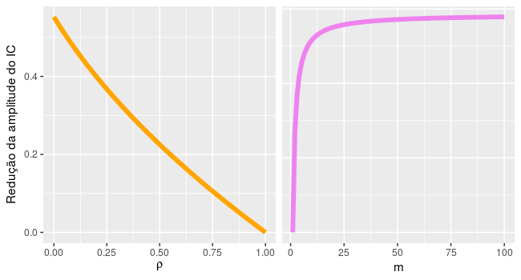

Figura 3: Comportamento da redução do IC variando $\rho$ e m

```r
red <- function(m, rho){
  red <-  (1 - sqrt(rho + (1-rho)/m))
}
red.rho <- Vectorize(red, "rho")
red.m <- Vectorize(red, "m")

red.r <- seq(0, 1, l = 1000) %>% red.rho(m = 5)
red.mm <- 1:100 %>% red.m(rho = 0.5)

p1 <- data.frame(s = seq(0, 1, l = 1000), r = red.r) %>%
  ggplot(aes(x = s, y = r)) +
  geom_line( colour = "orange", size = 2) +
  ylab("Redução da amplitude do IC") +
  xlab(expression(rho))


p2 <- data.frame(s = 1:100, r = red.mm) %>%
  ggplot(aes(x = s, y = r)) +
  geom_line( colour = "violet", size = 2) +
  xlab(expression(m))

gl <- lapply(list(p1, p2), ggplotGrob)

widths <- do.call(unit.pmax, lapply(gl, "[[", "widths"))
heights <- do.call(unit.pmax, lapply(gl, "[[", "heights"))
lg <- lapply(gl, function(g) {g$widths <- widths; g$heights <- heights; g})
gt = cbind(lg[[1]], lg[[2]][, -(1:3)], size = "first")

gt$widths[5] = unit(0, "lines")
grid.newpage()
grid.draw(gt)
```

Da equação de $\rho_m$, sabe-se que a confiabilidade média de m é a confiabilidade uma observação multiplicada por:
$$m/(1 + (m-1) \rho)$$

# Alocação ótima para estimação de $\rho$

- Quais devem ser o valores de m e n para que a variância de $\hat \rho$ seja mínima?

$$\hat \rho = \frac{QMA - QMR}{QMA + (m-1) QMR}$$

E

$$Var(\hat \rho) = \frac{2(1 - \rho)^2 [n + (N - n) \rho]^2}{N(N-n)(n-1)}$$

- Existe pelo menos um valor de n entre (1, N) que minimiza $\hat \rho$. Em Ching(1995), este valor é determinado como:

$$n_0 = \frac{N(N-1)\rho + 2}{(N+1) + (N- 1)\rho}$$

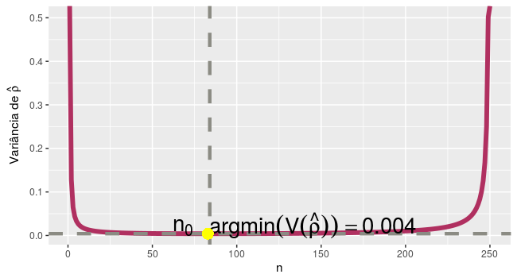

Figura 4: Comportamento de $V(\hat \rho)$ variando n

```r
hat.rho <- function(rho, n, N){
  r <-  (2*(1 - rho)^2 * (n + (N - n)  * rho)^2)/(N*(N-n)*(n-1))
}
hat.rho <- Vectorize(hat.rho, "n")

hr <- 1:250 %>% hat.rho(rho = 0.5, N = 250)

# n0 = (N(N-1) \rho + 2)/((N+1) + (N-1) \rho)
n0 <- (250 *  (250-1) * 0.5 + 2)/((250+1) + (250-1) * 0.5)

data.frame(s = 1:250, r = hr) %>%
  ggplot(aes(x = s, y = r)) +
  geom_line( colour = "maroon", size = 2) +
  ylab(expression("Variância de"~hat(rho))) +
  xlab("n") +
  geom_hline(aes(yintercept = min(hr)),
             linetype = "dashed", size = 1.5, color = "ivory4") +
  geom_vline(aes(xintercept = which.min(hr)),
             linetype = "dashed", size = 1.5, color = "ivory4") +
  annotate("text", y = min(hr) + 0.02 , x = 145,
           label = paste("argmin(V(hat(rho))) == ", round(min(hr), 4)),
           parse = TRUE, size = 7) +
    geom_point(aes(x = n0, y = 0.004),
             size = 4, colour = "yellow") +
    annotate("text", y = 0.018 , x = n0 - 15,
           label = paste0("n[0]"),
           parse = TRUE, size = 7)
```

Percebe-se que os valores de m e n dependem de $\rho$, a ser estimado. A seguir os autores mostram que é possível obtê-los sem considerar a correlação. Substituindo n por $n_0$ em $\hat \rho$, obtem-se a variância do planejamento ótimo como:

$$Var(\hat \rho | n = n_0) = \frac{8(1 - \rho)^2 [(N - 1) \rho + 1]}{(N-1)^2}$$
Que tem máximo quando:
$$\rho = \frac{N - 3}{3(N - 1)}$$

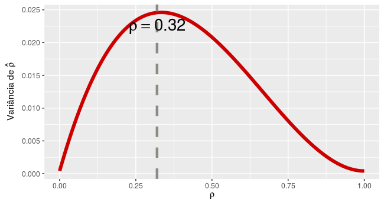

Figura 5: Comportamento de $V(\hat \rho | n = n_0)$ variando $\rho$

```r
v.rho <- function(rho, N){
  r <-  (8*((1 - rho)^2) * (N - 1)* rho + 1)/((N-1)^2)
}
v.rho <- Vectorize(v.rho, "rho")

vr <- seq(0, 1, l = 1000) %>% v.rho(N = 50)

# rho = (N - 3)*(3(N - 1)
rho  <-  (50 - 3)/(3*(50 - 1))

data.frame(s = seq(0, 1, l = 1000), r = vr) %>%
  ggplot(aes(x = s, y = r)) +
  geom_line( colour = "red3", size = 2) +
  ylab(expression("Variância de"~hat(rho))) +
  xlab(expression(rho)) +
  geom_vline(aes(xintercept = rho),
             linetype = "dashed", size = 1.5, color = "ivory4") +
  annotate("text", y =  0.0225, x = rho,
           label = paste("rho == ", round(rho, 2)),
           parse = TRUE, size = 7)
```

Substituindo na equação de $n_0$, obtemos os valores ótimo como sendo:

$$\begin{equation}
\begin{cases}
n_0 = (N+3)/4 \approx N/4 \\
\rho = (N-3)/[3(N-1)] \\
m = 4 \\
Var(\hat \rho | n = N/4) = \frac{2 (1 - \rho)^2 (1+3 \rho)^2}{3(N-4)}
\end{cases}
\end{equation}$$

# Estudo da confiabilidade das medidas de Dióxido de Nitrogênio

- Neste estudo, foi adotado o planejamento quase ótimo para estimar $\rho$.

```r
da <- read.table("da.txt", header = TRUE)
str(da)
```

```
'data.frame':   20 obs. of  2 variables:
 $ Local    : int  1 1 1 1 2 2 2 2 3 3 ...
 $ Concentra: num  171 155 136 153 68 ...
```

```r
# Resumo dos dados
tapply(da$Concentra, da$Local, summary)
```

```
$`1`
   Min. 1st Qu.  Median    Mean 3rd Qu.    Max.
  136.4   148.9   153.9   153.7   158.7   170.6

$`2`
   Min. 1st Qu.  Median    Mean 3rd Qu.    Max.
  66.40   67.60   69.15   68.95   70.50   71.10

$`3`
   Min. 1st Qu.  Median    Mean 3rd Qu.    Max.
  118.1   125.8   133.2   134.0   141.4   151.5

$`4`
   Min. 1st Qu.  Median    Mean 3rd Qu.    Max.
  103.8   136.6   148.3   138.6   150.3   153.9

$`5`
   Min. 1st Qu.  Median    Mean 3rd Qu.    Max.
  83.90   97.03  107.75  104.17  114.90  117.30
```

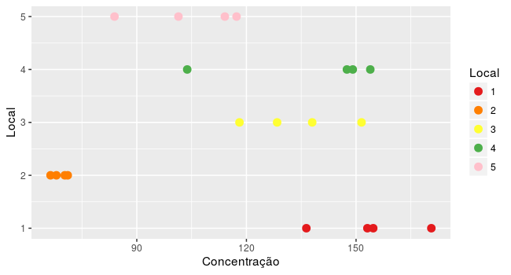

Figura 5: Gráfico de dispersão dos dados

```r
#--------------------------------------------
# Gráfico descritivo
#--------------------------------------------
da %>%
  ggplot(aes(x = Concentra, y = Local)) +
  geom_point(aes(colour = factor(Local)), size = 3) +
  scale_colour_manual(name = "Local",
                      values = c("#E41A1C", "#FF7F00", "#FFFF33",
                                "#4DAF4A", "pink")) +
  xlab("Concentração")
```

```r
#--------------------------------------------
da.new <- plyr::ddply(da, "Local", transform, m = mean(Concentra))
# SQResiduos
QMR <- sum((da.new$Concentra - da.new$m)^2) * (20 - 5)^(-1)

# SQA
ydd <- sum(da.new$Concentra)/20
QMA <- sum(4 * (da.new$m - ydd)^2)/((5 - 1)*4)

# Estimativa do coeficiente de correlação intraclasse
(rho.est <- (QMA - QMR)/(QMA + (4 -1) * QMR))
```

```
[1] 0.8202989
```

```r
# V(rho)
(v.rho <-  (2*(1 - rho.est)^2 * (1 + 3*rho.est)^2)/(3*(20-4)))
```

```
[1] 0.01611638
```

```r
rho.est.m <- (QMA - QMR)/(QMA + (4/4 -1) * QMR)

# Estimativa de m - confiabilidade = 0.9
(m <-  (0.9 * (1 - rho.est))/(rho.est * (1 - 0.9)))
```

```
[1] 1.971611
```

```r
# Redução da amplitude
(red <- 1 - (sqrt(rho.est + (1 - rho.est)/2)))
```

```
[1] 0.04598247
```

```r
# ----- Análise sem o local 2---------------------------------------------
da2 <- da %>% filter(Local != 2)

da.new2 <- plyr::ddply(da2, "Local", transform, m = mean(Concentra))

# SQResiduos
QMR <- sum((da.new2$Concentra - da.new2$m)^2) * (16 - 4)^(-1)

# SQA
ydd <- sum(da.new2$Concentra)/16
QMA <- sum(4 * (da.new2$m - ydd)^2)/((4 - 1)*4)

# Estimativa do coeficiente de correlação intraclasse
(rho.est <- (QMA - QMR)/(QMA + (4 -1) * QMR))
```

```
[1] 0.5491849
```

```r
# Estimativa de m - confiabilidade = 0.9
(m <-  (0.9 * (1 - rho.est))/(rho.est * (1 - 0.9)))
```

```
[1] 7.387924
```

No caso descrito como exemplo no artigo, encontra-se: $\hat \rho = 0.82$, $Var(\hat \rho) = 0.016$ e m ótimo como 2, para uma confiabilidade de 90%. Ou seja, se o número disponível de filtros for 20, devem ser selecionados 10 locais de coleta, sendo colocados 2 filtros em cada. Neste caso, obtém-se também que a redução do IC para a média é 4.6%. Ao desconsiderarmos o local 2, que tem valores bem menores que os outros, entretanto, temos $\hat \rho = 0.55$ e m ótimo valendo 8.

# Considerações finais

Conclue-se que o aumento na confiabilidade de uma resposta pode ser demonstrado também através do aumento da precisão da estimativa para $\mu$. Além disso, o conhecimento de $\rho$ é indispensável para quantificar o ganho obtido.